# UNIVERSIDADE FEDERAL DE GOIÁS

Instituto de Matématica e Estatística

Estatística I

Junho 2019

Material de Apoio

[figure not shown]

# Introdução ao R

## O que é R

O **R** não é apenas uma linguagem de programação, é também um ambiente integrado de desenvolvimento. É um software livre que foi derivado do software S, pelo qual John Chambers venceu o ACM Software Systems award. **R** é baseado em linhas de comandos e de acordo com seus criadores, é um software para manipulação de dados, cálculo e exibição gráfica.

O **R** base tem menos pacotes estatísticos **inclusos** em comparação com SPSS ou SAS, porém, é muito mais fácil de extendê-lo.

Atulamente, existem disponiveis no website CRAN aproximadamente 10 000 pacotes (Revolutionanalytics, 2017).

## R como calculadora

```r
2 + 2
```

```
## [1] 4
```

```r
5 - 10
```

```
## [1] -5
```

```r
3 * 2
```

```
## [1] 6
```

```r
80 / 100
```

```
## [1] 0.8
```

```r
2^10
```

```
## [1] 1024
```

```r
sqrt(49)
```

```
## [1] 7
```

```r
1/ 0
```

```
## [1] Inf
```

```r
sqrt(-1)
```

```
## [1] NaN
```

```r
x = 3

y = 2

x + y
```

```
## [1] 5
```

```r
round(pi,6)
```

```
## [1] 3.141593
```

## Objetos

### Vetores

Conjunto de elementos do mesma classe (logical, numeric, integer, double character)

1. A forma mais simples de se criar um vetor é usar a função de concatenação ``c()’’.

```r
value.num  = c(3,4,2,6,20)

value.num
```

```
## [1]  3  4  2  6 20
```

```r
value.char = c("koala", "kangaroo")

value.char
```

```
## [1] "koala"    "kangaroo"
```

```r
value.logical = c(FALSE, FALSE, TRUE, TRUE)

value.logical
```

```
## [1] FALSE FALSE  TRUE  TRUE
```

2. Segunda maneira de criar vetor no R: usando a função ``scan’’

```r
values = scan(text="
2
3
4
5"
)

values
```

```
## [1] 2 3 4 5
```

3. Outra opção usando comando ``rep’’

```r
rep(1,5)
```

```
## [1] 1 1 1 1 1
```

```r
rep(c(1,2),3)
```

```
## [1] 1 2 1 2 1 2
```

```r
rep(c(1,6),each=3)
```

```
## [1] 1 1 1 6 6 6
```

```r
rep(c(1,6),c(3,5))
```

```
## [1] 1 1 1 6 6 6 6 6
```

4. Outra opção usando comando ``seq’’

```r
seq(from=1,to=5)
```

```
## [1] 1 2 3 4 5
```

```r
seq(from=1, to=5, by=0.1)
```

```
##  [1] 1.0 1.1 1.2 1.3 1.4 1.5 1.6 1.7 1.8 1.9 2.0 2.1 2.2 2.3 2.4 2.5 2.6 2.7 2.8 2.9 3.0 3.1 3.2 3.3 3.4 3.5 3.6 3.7 3.8 3.9 4.0 4.1 4.2 4.3 4.4 4.5 4.6 4.7 4.8 4.9 5.0
```

```r
seq(from=1, to=5, length=10)
```

```
##  [1] 1.000000 1.444444 1.888889 2.333333 2.777778 3.222222 3.666667 4.111111 4.555556 5.000000
```

```r
rep(seq(from=1, to=5, length=10),each=2)
```

```
##  [1] 1.000000 1.000000 1.444444 1.444444 1.888889 1.888889 2.333333 2.333333 2.777778 2.777778 3.222222 3.222222 3.666667 3.666667 4.111111 4.111111 4.555556 4.555556 5.000000 5.000000
```

5. Outra opção usando comando ``:’’

```r
1:5
```

```
## [1] 1 2 3 4 5
```

```r
c(1:5,10)
```

```
## [1]  1  2  3  4  5 10
```

#### Operações com Vetores

```r
x = 1:4

y = 5:8

x + y
```

```
## [1]  6  8 10 12
```

```r
2*x +1
```

```
## [1] 3 5 7 9
```

```r
x * y
```

```
## [1]  5 12 21 32
```

```r
x / y
```

```
## [1] 0.2000000 0.3333333 0.4285714 0.5000000
```

```r
log(x)
```

```
## [1] 0.0000000 0.6931472 1.0986123 1.3862944
```

```r
log(x,10)
```

```
## [1] 0.0000000 0.3010300 0.4771213 0.6020600
```

```r
sum(x)
```

```
## [1] 10
```

```r
mean(x)
```

```
## [1] 2.5
```

```r
prod(x)
```

```
## [1] 24
```

```r
var(x)
```

```
## [1] 1.666667
```

### Matriz

Conjunto de elementos dispostos em linhas e colunas, em que todos os elementos são do mesmo tipo

```r
mat.num  = matrix(c(1:16),4,4)

mat.num
```

```
##      [,1] [,2] [,3] [,4]
## [1,]    1    5    9   13
## [2,]    2    6   10   14
## [3,]    3    7   11   15
## [4,]    4    8   12   16
```

```r
mat.char = matrix(LETTERS[1:4],2,2)

mat.char
```

```
##      [,1] [,2]
## [1,] "A"  "C"
## [2,] "B"  "D"
```

#### Manipulando Matrizes

```r
#Criando nomes para as linhas de uma matriz

rownames(mat.num) = c("Sao Paulo", "Americana", "Piracicaba", "Madson" )

colnames(mat.num) = 1:4

mat.num
```

```
##            1 2  3  4
## Sao Paulo  1 5  9 13
## Americana  2 6 10 14
## Piracicaba 3 7 11 15
## Madson     4 8 12 16
```

```r
#Multiplicacao elemento a elemento

mat.num2 = diag(seq(10,40,by=10))

mat.num2
```

```
##      [,1] [,2] [,3] [,4]
## [1,]   10    0    0    0
## [2,]    0   20    0    0
## [3,]    0    0   30    0
## [4,]    0    0    0   40
```

```r
mat.num3 = mat.num * mat.num2

mat.num3
```

```
##             1   2   3   4
## Sao Paulo  10   0   0   0
## Americana   0 120   0   0
## Piracicaba  0   0 330   0
## Madson      0   0   0 640
```

```r
#Multiplicacao de Matrizes

iden = diag(4)

iden
```

```
##      [,1] [,2] [,3] [,4]
## [1,]    1    0    0    0
## [2,]    0    1    0    0
## [3,]    0    0    1    0
## [4,]    0    0    0    1
```

```r
mat.num%*%iden
```

```
##            [,1] [,2] [,3] [,4]
## Sao Paulo     1    5    9   13
## Americana     2    6   10   14
## Piracicaba    3    7   11   15
## Madson        4    8   12   16
```

```r
#Acessando elementos das matrizes

#Um elemento
mat.num[1,1]
```

```
## [1] 1
```

```r
#Linhas
mat.num[1,]
```

```
##  1  2  3  4
##  1  5  9 13
```

```r
#Colunas
mat.num[,3]
```

```
##  Sao Paulo  Americana Piracicaba     Madson
##          9         10         11         12
```

```r
#Sub Matrizes

mat.num[c(1,3,4), c(2,1,4)]
```

```
##            2 1  4
## Sao Paulo  5 1 13
## Piracicaba 7 3 15
## Madson     8 4 16
```

```r
mat.num[c(T,F,T,T), c(T,T,F,T)]
```

```
##            1 2  4
## Sao Paulo  1 5 13
## Piracicaba 3 7 15
## Madson     4 8 16
```

```r
mat.num[-c(1,3,4), -c(2,1,4)]
```

```
## [1] 10
```

### Data.frames

São Similares as matrizes no entanto permite que as colunas tenham diferentes tipos

```r
data(iris)

iris
```

```
##     Sepal.Length Sepal.Width Petal.Length Petal.Width    Species
## 1            5.1         3.5          1.4         0.2     setosa
## 2            4.9         3.0          1.4         0.2     setosa
## 3            4.7         3.2          1.3         0.2     setosa
## 4            4.6         3.1          1.5         0.2     setosa
## 5            5.0         3.6          1.4         0.2     setosa
## 6            5.4         3.9          1.7         0.4     setosa
## 7            4.6         3.4          1.4         0.3     setosa
## 8            5.0         3.4          1.5         0.2     setosa
## 9            4.4         2.9          1.4         0.2     setosa
## 10           4.9         3.1          1.5         0.1     setosa
## 11           5.4         3.7          1.5         0.2     setosa
## 12           4.8         3.4          1.6         0.2     setosa
## 13           4.8         3.0          1.4         0.1     setosa
## 14           4.3         3.0          1.1         0.1     setosa
```

[output cut: 136 more lines]

```r
iris$Sepal.Length
```

```
##   [1] 5.1 4.9 4.7 4.6 5.0 5.4 4.6 5.0 4.4 4.9 5.4 4.8 4.8 4.3 5.8 5.7 5.4 5.1 5.7 5.1 5.4 5.1 4.6 5.1 4.8 5.0 5.0 5.2 5.2 4.7 4.8 5.4 5.2 5.5 4.9 5.0 5.5 4.9 4.4 5.1 5.0 4.5 4.4 5.0 5.1 4.8 5.1 4.6 5.3 5.0 7.0 6.4 6.9 5.5 6.5 5.7 6.3 4.9 6.6 5.2 5.0 5.9 6.0 6.1 5.6 6.7 5.6 5.8 6.2 5.6 5.9 6.1 6.3…
```

```r
iris$teste = TRUE

iris
```

```
##     Sepal.Length Sepal.Width Petal.Length Petal.Width    Species teste
## 1            5.1         3.5          1.4         0.2     setosa  TRUE
## 2            4.9         3.0          1.4         0.2     setosa  TRUE
## 3            4.7         3.2          1.3         0.2     setosa  TRUE
## 4            4.6         3.1          1.5         0.2     setosa  TRUE
## 5            5.0         3.6          1.4         0.2     setosa  TRUE
## 6            5.4         3.9          1.7         0.4     setosa  TRUE
## 7            4.6         3.4          1.4         0.3     setosa  TRUE
## 8            5.0         3.4          1.5         0.2     setosa  TRUE
## 9            4.4         2.9          1.4         0.2     setosa  TRUE
## 10           4.9         3.1          1.5         0.1     setosa  TRUE
## 11           5.4         3.7          1.5         0.2     setosa  TRUE
## 12           4.8         3.4          1.6         0.2     setosa  TRUE
## 13           4.8         3.0          1.4         0.1     setosa  TRUE
## 14           4.3         3.0          1.1         0.1     setosa  TRUE
```

[output cut: 136 more lines]

### List

Generalização dos vetores no sentido que uma lista é uma coleção de objetos

```r
A = list(x = 1:4, y = matrix(1:4,2,2), v = list(A=4,B=5))

A
```

```
## $x
## [1] 1 2 3 4
##
## $y
##      [,1] [,2]
## [1,]    1    3
## [2,]    2    4
##
## $v
## $v$A
## [1] 4
##
## $v$B
## [1] 5
```

```r
A[[1]]
```

```
## [1] 1 2 3 4
```

```r
A[[3]]
```

```
## $A
## [1] 4
##
## $B
## [1] 5
```

```r
A$x
```

```
## [1] 1 2 3 4
```

```r
A$y
```

```
##      [,1] [,2]
## [1,]    1    3
## [2,]    2    4
```

```r
B = list(s = 1:5, r = 2)

Q = c(A,B)

Q
```

```
## $x
## [1] 1 2 3 4
##
## $y
##      [,1] [,2]
## [1,]    1    3
## [2,]    2    4
##
## $v
## $v$A
## [1] 4
##
## $v$B
## [1] 5
##
##
## $s
## [1] 1 2 3 4 5
##
## $r
## [1] 2
```

## Instalando pacotes

```r
install.packages("tidyverse")
install.packages("readxl")
```

## Lendo dados

### Arquivos .txt

A função `read.table()` é u uma das principais funções do R; Importa dados para memoria RAM do computador. Cuidado ao armazenar grande quantidade de dados! Principais argumentos da função: file, header, sep, row.names, nrows.

Exemplo arquivo: “softdrin.txt”

```r
dados  = read.table(file = "softdrin.txt", header = TRUE)
head(dados)
```

```
##    Time Cases Distance
## 1 16.68     7      560
## 2 11.50     3      220
## 3 12.03     3      340
## 4 14.88     4       80
## 5 13.75     6      150
## 6 18.11     7      330
```

### Arquivos .csv

As funções : `read.csv()` e `read.csv2()` funcionam de forma similar a função `read.table()`, `read.csv()` considera a virgula como separador das colunas e o ponto como separador dos numeros decimais, ``read.csv2()’’ considera o ponto e virgula como separador das colunas e a virgula como separador dos numeros decimais.

Exemplos: Arquivos “forestfires.csv”, “forestfires.csv2” e “forestfires.xlsx”

```r
dados_csv  = read.csv(file = "forestfires.csv", header = TRUE)
head(dados_csv)
```

```
##   X Y month day FFMC  DMC    DC  ISI temp RH wind rain area
## 1 7 5   mar fri 86.2 26.2  94.3  5.1  8.2 51  6.7  0.0    0
## 2 7 4   oct tue 90.6 35.4 669.1  6.7 18.0 33  0.9  0.0    0
## 3 7 4   oct sat 90.6 43.7 686.9  6.7 14.6 33  1.3  0.0    0
## 4 8 6   mar fri 91.7 33.3  77.5  9.0  8.3 97  4.0  0.2    0
## 5 8 6   mar sun 89.3 51.3 102.2  9.6 11.4 99  1.8  0.0    0
## 6 8 6   aug sun 92.3 85.3 488.0 14.7 22.2 29  5.4  0.0    0
```

```r
dados_csv2  = read.csv2(file = "forestfires2.csv", header = TRUE)
head(dados_csv2)
```

```
##   X Y month day FFMC  DMC    DC  ISI temp RH wind rain area
## 1 7 5   mar fri 86.2 26.2  94.3  5.1  8.2 51  6.7  0.0    0
## 2 7 4   oct tue 90.6 35.4 669.1  6.7 18.0 33  0.9  0.0    0
## 3 7 4   oct sat 90.6 43.7 686.9  6.7 14.6 33  1.3  0.0    0
## 4 8 6   mar fri 91.7 33.3  77.5  9.0  8.3 97  4.0  0.2    0
## 5 8 6   mar sun 89.3 51.3 102.2  9.6 11.4 99  1.8  0.0    0
## 6 8 6   aug sun 92.3 85.3 488.0 14.7 22.2 29  5.4  0.0    0
```

```r
dados_excel = read_excel("forestfires.xlsx")
```

`read.table()` pode ler arquivos diretamente da internet

```r
fl2000<-read.table("http://faculty.washington.edu/tlumley/data/FLvote.dat", header=TRUE)
head(fl2000)
```

```
##            GORE   BUSH BUCHANAN NADER NELSON MCCOLLUM LOGAN
## ALACHUA   47365  34124      263  3226  49091    31060  1735
## BAKER      2392   5610       73    53   3104     4578    50
## BAY       18850  38637      248   828  22914    33901   358
## BRADFORD   3075   5414       65    84   4118     4699    92
## BREVARD   97318 115185      570  4470 112255    98813  2304
## BROWARD  386565 177323      788  7101 377081   174980  6166
```

## Estatística Descritiva

Estatística Descritiva é a **etapa inicial** da análise utilizada para descrever e **resumir os dados**. A disponibilidade de uma grande quantidade de dados e de métodos computacionais muito eficientes revigorou esta área da estatística (Lachos).

### Variáveis

Qualquer característica associada a uma população.

As variáveis podem ser classificadas em:

1. Qualitativas: são as características definidas por várias categorias, ou seja, representam uma classificação dos indivíduos. Exemplo: Região de procedencia e grau de instrução.

   1.1 Nominais: Não existe nenhuma ordenação nas possíveis realizações. Exemplo: Região de procedencia. 1.2 Ordinais: Existe uma ordem de seus resultados. Exemplo: Grau de instrução
2. Quantitativas: são as características que podem ser medidas em uma escala quantitativa. Exemplo: Numero de filhos e Salarios.

   2.1 Discretas: cujos possíveis valores formam um conjunto finito ou enumerável. Exemplo: Numero de filhos. 2.2 Contínuas: cujos possíveis valores pertencem a um intervalo de numeros reais. Exemplo: Salario, estatura e peso

> Exemplo: Tabela 2.1 do livro Estatistica Basica (Morettin & Bussab)

```r
#Ler os dados
tab21 = read.table("tabela2.1.txt", sep=";", dec=",", header = TRUE, fileEncoding = "UTF-8")

#Classe do objeto
class(tab21)
```

```
## [1] "data.frame"
```

```r
#Nomes das colunas do objeto
names(tab21)
```

```
## [1] "N"               "estado_civil"    "grau_instrucao"  "n_filhos"        "salario"         "idade_anos"      "idade_meses"     "reg_procedencia"
```

```r
#Verificar o tipo de variável de cada coluna do data.frame
str(tab21)
```

```
## 'data.frame':    36 obs. of  8 variables:
##  $ N              : int  1 2 3 4 5 6 7 8 9 10 ...
##  $ estado_civil   : Factor w/ 2 levels "casado","solteiro": 2 1 1 2 2 1 2 2 1 2 ...
##  $ grau_instrucao : Factor w/ 3 levels "ensino fundamental",..: 1 1 1 2 1 1 1 1 2 2 ...
##  $ n_filhos       : int  NA 1 2 NA NA 0 NA NA 1 NA ...
##  $ salario        : num  4 4.56 5.25 5.73 6.26 6.66 6.86 7.39 7.59 7.44 ...
##  $ idade_anos     : int  26 32 36 20 40 28 41 43 34 23 ...
##  $ idade_meses    : int  3 10 5 10 7 0 0 4 10 6 ...
##  $ reg_procedencia: Factor w/ 3 levels "capital","interior",..: 2 1 1 3 3 2 2 1 1 3 ...
```

```r
#Imprimir as primeiras linhas do data.frame
head(tab21)
```

```
##   N estado_civil     grau_instrucao n_filhos salario idade_anos idade_meses reg_procedencia
## 1 1     solteiro ensino fundamental       NA    4.00         26           3        interior
## 2 2       casado ensino fundamental        1    4.56         32          10         capital
## 3 3       casado ensino fundamental        2    5.25         36           5         capital
## 4 4     solteiro       ensino médio       NA    5.73         20          10           outra
## 5 5     solteiro ensino fundamental       NA    6.26         40           7           outra
## 6 6       casado ensino fundamental        0    6.66         28           0        interior
```

```r
#Sumário dos dados
summary(tab21)
```

```
##        N           estado_civil            grau_instrucao    n_filhos       salario         idade_anos     idade_meses     reg_procedencia
##  Min.   : 1.00   casado  :20    ensino fundamental:12     Min.   :0.00   Min.   : 4.000   Min.   :20.00   Min.   : 0.000   capital :11
##  1st Qu.: 9.75   solteiro:16    ensino médio      :18     1st Qu.:1.00   1st Qu.: 7.553   1st Qu.:30.00   1st Qu.: 3.750   interior:12
##  Median :18.50                  superior          : 6     Median :2.00   Median :10.165   Median :34.50   Median : 6.000   outra   :13
##  Mean   :18.50                                            Mean   :1.65   Mean   :11.122   Mean   :34.58   Mean   : 5.611
##  3rd Qu.:27.25                                            3rd Qu.:2.00   3rd Qu.:14.060   3rd Qu.:40.00   3rd Qu.: 8.000
##  Max.   :36.00                                            Max.   :5.00   Max.   :23.300   Max.   :48.00   Max.   :11.000
##                                                           NA's   :16
```

```r
#Correlação entre duas variáveis
cor(tab21$idade_anos, tab21$salario)
```

```
## [1] 0.3633622
```

```r
#Tabela de Frequencia Absoluta
tabFAbs = table(tab21$reg_procedencia)

tabFAbs
```

```
##
##  capital interior    outra
##       11       12       13
```

```r
#Tabela de Frequencia Relativa
tabFRel = prop.table(tabFAbs)

tabFRel
```

```
##
##   capital  interior     outra
## 0.3055556 0.3333333 0.3611111
```

### Gráficos para variáveis qualitativas e quantitativas discretas

#### Gráficos de barras

O gráfico em barras consiste em construir retangulos, em que uma das dimensões é proporcional a frequencia absoluta ou relativa e a outra é arbitraria, porem igual para todos os retangulos. Essas barras são dispostas paralelamente umas às outras

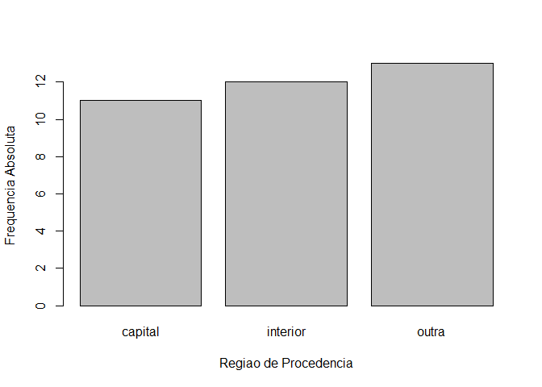

```r
#Grafico de barras - Frequencia Absoluta
barplot(tabFAbs, xlab = "Regiao de Procedencia", ylab = "Frequencia Absoluta")
```

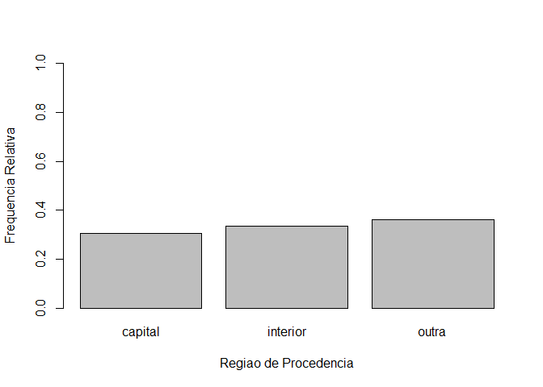

```r
#Graficos de barras - Frequencia Relativa
barplot(tabFRel, xlab = "Regiao de Procedencia", ylab = "Frequencia Relativa", ylim=c(0,1))
```

#### Gráfico de composição

Gráfico de composição em setores, sendo em forma de “pizza” o mais conhecido, consiste num circulo de raio arbitrario, representando o todo, dividido em setores, que correspondem as partes de maneira proporcional.

```r
#Rotulo com as porcentagens

names(tabFAbs)
```

```
## [1] "capital"  "interior" "outra"
```

```r
scales::percent(as.numeric(tabFRel))
```

```
## [1] "30.56%" "33.33%" "36.11%"
```

```r
lab = paste0(names(tabFAbs)," ",scales::percent(as.numeric(tabFRel)))

lab
```

```
## [1] "capital 30.56%"  "interior 33.33%" "outra 36.11%"
```

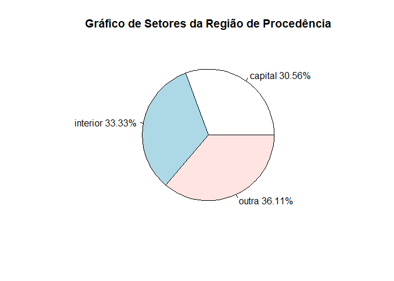

```r
#Grafico de pizza
pie(tabFAbs, labels = lab, main = "Gráfico de Setores da Região de Procedência")
```

### Gráficos para variáveis quantitativas contínuas

#### Histogramas

Um histograma é uma representação visual da distribuição de um cojunto de dados. Matematicamente, o histograma é um gráfico de barras contínuas, com as bases proporcionais aos intervalos de classes $\Delta$ e a área de cada retangulo proporcional à respectiva frequencia $f_i$. Para que a área do retangulo respectivo seja proporcional a $f_i$, a sua altura deve ser proporcional a $\frac{f_i}{\Delta}$, que é chamada densidade de frequencia da i-ésima classe. Com essa convenção, a área total do histograma será igual a 1.

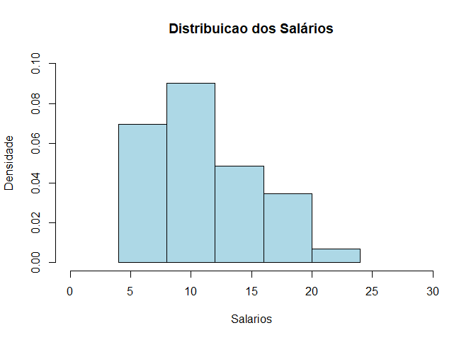

```r
#Histogramas - Estatistica Basica Morettin & Bussab

hist(tab21$salario,breaks=seq(4,24,by=4), prob=TRUE, xlab="Salarios",
     ylab = "Densidade", col="lightblue", ylim=c(0,0.1), xlim=c(0,30),
     main="Distribuicao dos Salários")
```

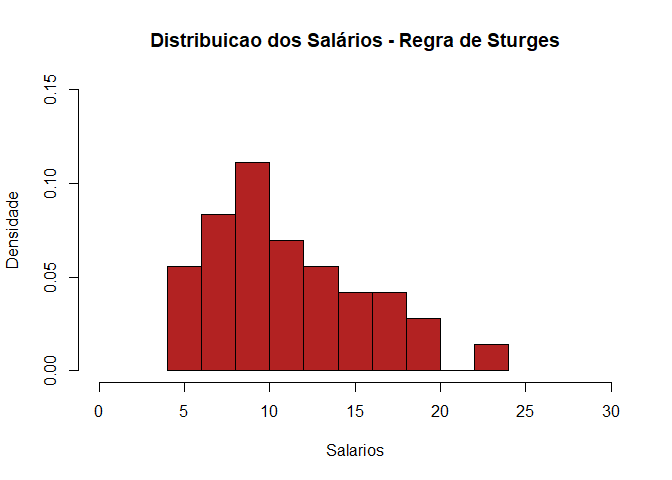

```r
#Faz um histograma para os dados de salario, que o eixo das abcissas
#inicia no ponto 4 e termina no 24 com intervalos de classe de 4 unidades.
#O limite inferior do eixo das ordenadas eh zero e o limite superior eh
#0.1
#O limite inferior do eixo das abscissas eh zero e o limite superior eh
#30

#Histograma com a regra de Sturges

hist(tab21$salario,breaks= nclass.Sturges(tab21$salario), prob=TRUE, xlab="Salarios", ylab = "Densidade", col="firebrick", ylim=c(0,0.15), xlim=c(0,30),
     main="Distribuicao dos Salários - Regra de Sturges")
```

#### BoxPlot

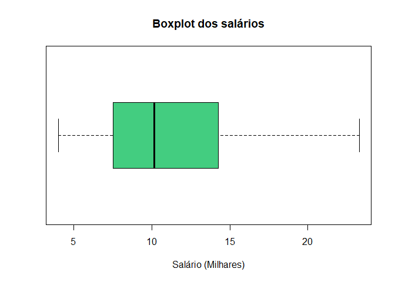

```r
boxplot(tab21$salario, main = "Boxplot dos salários", xlab = "Salário (Milhares)", col = "seagreen3", horizontal = T)
```

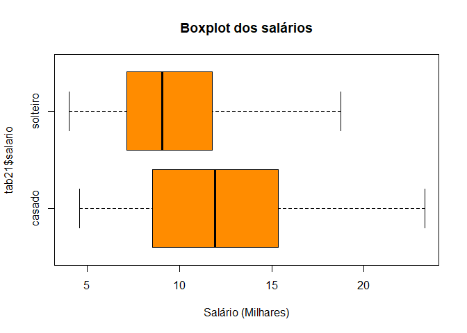

```r
boxplot(tab21$salario ~ tab21$estado_civil, main = "Boxplot dos salários", xlab = "Salário (Milhares)", col = "darkorange", horizontal = T)
```

#### Gráfico de dispersão

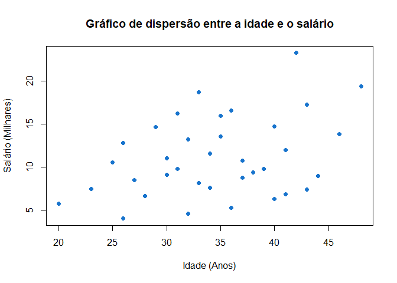

```r
plot(tab21$idade_anos, tab21$salario,
     main = "Gráfico de dispersão entre a idade e o salário",
     xlab = "Idade (Anos)",
     ylab = "Salário (Milhares)",
     pch = 19,
     col="Dodgerblue3")
```

#### Gráficos múltiplos

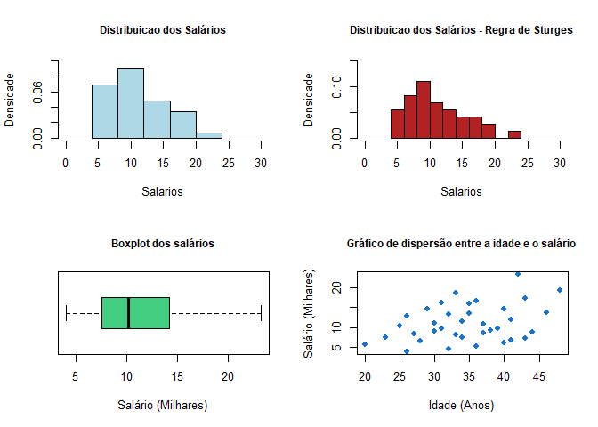

```r
par(mfrow=c(2,2))

hist(tab21$salario,
     breaks=seq(4,24,by=4),
     prob=TRUE,
     xlab="Salarios",
     ylab = "Densidade",
     col="lightblue",
     ylim=c(0,0.1),
     xlim=c(0,30),
     cex.main = .9,
     main="Distribuicao dos Salários")

hist(tab21$salario,
     breaks= nclass.Sturges(tab21$salario),
     prob=TRUE,
     xlab="Salarios",
     ylab = "Densidade",
     col="firebrick",
     ylim=c(0,0.15),
     xlim=c(0,30),
     cex.main = .9,
     main="Distribuicao dos Salários - Regra de Sturges")

boxplot(tab21$salario,
        main = "Boxplot dos salários",
        xlab = "Salário (Milhares)",
        cex.main = .9,
        col = "seagreen3",
        horizontal = T)

plot(tab21$idade_anos, tab21$salario,
     main = "Gráfico de dispersão entre a idade e o salário",
     xlab = "Idade (Anos)",
     ylab = "Salário (Milhares)",
     pch = 19, cex.main = .9,
     col="Dodgerblue3")
```

Feito por [Rodrigo R. Cardoso](https://github.com/rrcardoso)

*rcardosofsa@gmail.com*